# NOAA Storm Data Analysis

Vladimír Tomeček

Saturday, March 21, 2015

# Synopsis

In this report we will explore the U.S. National Oceanic and Atmospheric Administration’s (NOAA) storm database in order to find out:

1. Which types of events are most harmful with respect to population health
2. Which types of events have the greatest economic consequences

First we will split the data into 49 Event Types according to `Storm Data Documentation`, then we will manually check top values in each category in order to find corrupted data that may affect out analysis and finally we will summarize and visualize the data.

Our analysis will show that tornadoes are top killers followed by heats. Most economic damage is caused by hurricanes, tornadoes and floods. Droughts did greatest damage on crops.

# Data processing

### Data

Our data comes from [U.S. National Oceanic and Atmospheric Administration’s (NOAA) storm database](https://d396qusza40orc.cloudfront.net/repdata%2Fdata%2FStormData.csv.bz2). The database contains 902,297 observations of 37 variables from years 1950 to 2011.

### Data loading

We are only interesting in some variables (BGN_DATE, STATE, EVTYPE, FATALITIES, INJURIES, PROPDMG, PROPDMGEXP, CROPDMG, CROPDMGEXP), so to speed-up the loading process and to save some space I will load the data like this:

```r
data <- read.csv('repdata-data-StormData.csv.bz2',
            colClasses = c(
                # STATE__ - EVTYPE
                'NULL', 'character', 'NULL', 'NULL', 'NULL', 'NULL', 'factor', 'factor',
                # BGN_RANGE - END_LOCATI
                'NULL', 'NULL', 'NULL', 'NULL', 'NULL', 'NULL', 'NULL', 'NULL', 'NULL', 'NULL',
                # LENGTH - MAG
                'NULL', 'NULL', 'NULL', 'NULL',
                # FATALITIES - CROPDMGEXP
                'numeric', 'numeric', 'numeric', 'factor', 'numeric', 'factor',
                # WFO-REFNUM
                'NULL', 'NULL', 'NULL', 'NULL', 'NULL', 'NULL', 'NULL', 'NULL', 'NULL'
            )
        )
```

### Data transformation - damage costs

Information about damage costs is split to two fields (damage, exponent), so we need to decode this exponent and calculate total damage.

```r
## Replace K, M, B... with numerical values
require(plyr)
data$PROPDMGEXP <- as.integer(as.character (
    revalue(data$PROPDMGEXP, c("H"="2", "h"=2, "K"=3, "k"=3, "M"=6, "m"=6, "B"=9))
))
data$CROPDMGEXP <- as.integer(as.character (
    revalue(data$CROPDMGEXP, c("H"="2", "h"=2, "K"=3, "k"=3, "M"=6, "m"=6, "B"=9))
))

## Substitute NAs with 0s
data$PROPDMGEXP[is.na(data$PROPDMGEXP)] <- 0
data$CROPDMGEXP[is.na(data$CROPDMGEXP)] <- 0

## Calculate total damage
data$PROPDMG <- data$PROPDMG * 10^data$PROPDMGEXP
data$CROPDMG <- data$CROPDMG * 10^data$CROPDMGEXP
```

### Data transformation - EVTYPE

```r
nrow(table(data$EVTYPE))
```

```
## [1] 985
```

Our table shows 985 distinct types of events, we want to transform these events to match the `Storm Data Event Table` on page 6 of [Storm Data Documentation](https://d396qusza40orc.cloudfront.net/repdata%2Fpeer2_doc%2Fpd01016005curr.pdf), which consist of 48 events.

First we create `EVTYPE` data frame consisting of all 985 distinct types. On this data frame, we will do all the pattern matching and substitution and when we will be ready we will update the `data` data frame in single pass.

```r
EVTYPE <- data.frame(stringsAsFactors = FALSE, oldname = names(table(data$EVTYPE)))
# transform the old name little bit to facilitate the pattern matching
# to uppercase & replace TSTM with THUNDERSTORM & left trim
EVTYPE$tmp <- sub("^[[:space:]]+", "",
              sub("TSTM", "THUNDERSTORM",
              toupper(EVTYPE$oldname)
              ))
# place for new names
EVTYPE$newname <- rep("", nrow(EVTYPE))
```

985 is quite a lot of records so we want to match most of these records automaticaly. We create `TARGET` data frame, containing target event table (ordered by length of string) and we run agrep (approximate grep) for each record in this table.

```r
TARGET <- data.frame(stringsAsFactors = FALSE, name = c(
    "Astronomical Low Tide", "Avalanche", "Blizzard", "Coastal Flood",  "Cold/Wind Chill",
    "Debris Flow", "Dense Fog", "Dense Smoke", "Drought", "Dust Devil", "Dust Storm",
    "Excessive Heat", "Extreme Cold/Wind Chill", "Flash Flood", "Flood", "Frost/Freeze",
    "Funnel Cloud", "Freezing Fog", "Hail", "Heat", "Heavy Rain", "Heavy Snow", "High Surf",
    "High Wind", "Hurricane (Typhoon)", "Ice Storm", "Lake-Effect Snow", "Lakeshore Flood",
    "Lightning", "Marine Hail", "Marine High Wind", "Marine Strong Wind", "Marine Thunderstorm Wind",
    "Rip Current", "Seiche", "Sleet", "Storm Surge/Tide", "Strong Wind", "Thunderstorm Wind",
    "Tornado", "Tropical Depression", "Tropical Storm", "Tsunami", "Volcanic Ash", "Waterspout",
    "Wildfire", "Winter Storm", "Winter Weather"))
TARGET$length <- nchar(TARGET$name)
TARGET <- TARGET[order(-TARGET$length),]

for (pattern in TARGET$name) {
    # match at the beginning of the string
    ids <- grep(paste0("^", toupper(pattern)), EVTYPE$tmp)
    EVTYPE$newname[ids] <- pattern
    # or match anywhere, but new name should be empty yet
    ids <- agrep(toupper(pattern), EVTYPE$tmp[EVTYPE$newname==""])
    EVTYPE$newname[EVTYPE$newname==""][ids] <- pattern
}

## We can now view the result and decide what to do next
#View(EVTYPE)
```

There is still a lot of records that cannot be matched automatically, plus our agrep introduced some errors so now we need to match the rest manually.

```r
# replace all records in EVTYPE data frame
replace_all <- function(search, replace) {
    EVTYPE$newname[grep(search, EVTYPE$tmp)] <<- replace
}

# replace only those records which have newname empty yet
replace_empty <- function(search, replace) {
    EVTYPE$newname[EVTYPE$newname==""][grep(search, EVTYPE$tmp[EVTYPE$newname==""])] <<- replace
}

EVTYPE$newname[agrep(toupper("Wind Chill"), EVTYPE$tmp)] <- "Cold/Wind Chill"
EVTYPE$newname[agrep(toupper("Extreme Wind Chill"), EVTYPE$tmp)] <- "Extreme Cold/Wind Chill"
replace_all("FLASH", "Flash Flood")
replace_empty("DUST", "Dust Storm")
replace_empty("^COASTAL", "Coastal Flood")
replace_empty("COLD", "Cold/Wind Chill")
replace_empty("DRY", "Drought")
replace_empty("FREEZ", "Frost/Freeze")
replace_empty("FROST", "Frost/Freeze")
replace_empty("ICE", "Frost/Freeze")
replace_empty("ICY", "Frost/Freeze")
replace_empty("SNOW", "Winter Weather")
replace_empty("PRECIP", "Heavy Rain")
replace_empty("RAIN", "Heavy Rain")
replace_empty("WARM", "Heat")
replace_empty("WET", "Heavy Rain")
replace_empty("HOT", "Heat")
replace_empty("WIND", "Strong Wind")
replace_empty("^WINT.*MIX$", "Winter Weather")
replace_empty("WALL CLOUD", "Funnel Cloud")
replace_all("^ASTRONOMICAL HIGH TIDE", "High Surf")
replace_all("^BEACH EROS", "High Surf")
replace_all("^BEACH FLOOD", "Coastal Flood")
replace_all("^BELOW NORMAL", "Drought")
replace_all("^BLIZZARD", "Blizzard")
replace_all("^BLOW-OUT TIDE", "Astronomical Low Tide")
replace_all("^BRUSH FIRE", "Wildfire")
replace_all("^COASTAL EROSION", "Coastal Flood")
replace_all("^COASTAL SURGE", "Storm Surge/Tide")
replace_all("^COASTAL/TIDAL", "Storm Surge/Tide")
replace_all("^COLD AIR FUNNEL", "Funnel Cloud")
replace_all("^COLD WEATHER", "Cold/Wind Chill")
replace_all("^COOL", "Cold/Wind Chill")
replace_all("^CSTL FLOOD", "Coastal Flood")
replace_all("^DAM FAIL", "")
replace_all("^DOWNBURST", "Thunderstorm Wind")
replace_all("^DRIEST", "Drought")
replace_all("^DRY MICROBURST", "Thunderstorm Wind")
replace_all("^DRY WEATHER", "Drought")
replace_all("^EROSION", "Coastal Flood")
replace_all("^EXCESSIVE [PR]", "Heavy Rain")
replace_all("^EXCESSIVE WET", "")
replace_all("^EXTENDED COLD", "Extreme Cold/Wind Chill")
replace_all("^EXTREME COLD", "Extreme Cold/Wind Chill")
replace_all("^EXTREME WIND", "Extreme Cold/Wind Chill")
replace_all("^EXTREME HEAT", "Excessive Heat")
replace_all("^FOG", "Dense Fog")
replace_all("^FOG AND COLD", "Freezing Fog")
replace_all("^FOREST FIRE", "Wildfire")
replace_all("^FREEZING RAIN", "Winter Weather")
replace_all("^FREEZING RAIN.*SLEET.*", "Sleet")
replace_all("^FUNNEL", "Funnel Cloud")
replace_all("^GLAZE", "Freezing Fog")
replace_all("^GRADIENT WIND", "Tropical Depression")
replace_all("^GRASS FIRE", "Wildfire")
replace_all("^GUSTNADO", "Thunderstorm Wind")
replace_all("^GUSTY WIND", "Strong Wind")
replace_all("^HAZARDOUS SURF", "High Surf")
replace_all("^HEAVY LAKE", "Lake-Effect Snow")
replace_all("^HEAVY SHOWER", "Heavy Rain")
replace_all("^HEAVY SEAS", "Coastal Flood")
replace_all("^HEAVY SURF", "High Surf")
replace_all("^HEAVY PRECIP", "Heavy Rain")
replace_all("^HEAVY WET SNOW", "Heavy Snow")
replace_all("^HEAVY SWELL", "High Surf")
replace_all("^HIGH (\ ?SWELLS|TIDES|WAVES|SEAS|WATER)", "High Surf")
replace_all("^HIGH TEMP", "Excessive Heat")
replace_all("^HOT SPELL", "Heat")
replace_all("^HURRICANE", "Hurricane (Typhoon)")
replace_all("^HVY RAIN", "Heavy Rain")
replace_all("^HYPER", "Excessive Heat")
replace_all("^HYPO", "Extreme Cold/Wind Chill")
replace_all("^ICE PELLETS", "Sleet")
replace_all("^ICE FOG", "Freezing Fog")
replace_all("^ICE STORM", "Ice Storm")
replace_all("^LAKE FLOOD", "Lakeshore Flood")
replace_all("^LOW TEMPERATURE", "Cold/Wind Chill")
replace_all("^MICROBURST", "Thunderstorm Wind")
replace_all("^MUD", "Debris Flow")
replace_all("^LAND", "Debris Flow")
replace_all("^RAIN", "Heavy Rain")
replace_all("^RAPIDLY RISING", "Storm Surge/Tide")
replace_all("^RECORD (\ ?COLD|COOL|LOW)", "Extreme Cold/Wind Chill")
replace_all("^RECORD HEAT", "Excessive Heat")
replace_all("^RECORD HIGH", "Excessive Heat")
replace_all("^RECORD TEMP", "Excessive Heat")
replace_all("^RECORD WARM", "Excessive Heat")
replace_all("^RECORD LOW RAINFALL", "Drought")
replace_all("^REMNANTS", "Hurricane (Typhoon)")
replace_all("^ROCK SLIDE", "Debris Flow")
replace_all("^ROUGH", "High Surf")
replace_all("^RURAL FLOOD", "Heavy Rain")
replace_all("^SEVERE THUNDER", "Thunderstorm Wind")
replace_all("^SMALL STREAM", "Heavy Rain")
replace_all("^SML STREAM", "Heavy Rain")
replace_all("^SMOKE", "Dense Smoke")
replace_all("^SOUTHEAST", "")
replace_all("^STORM FORCE", "Tropical Storm")
replace_all("^STORM SURGE", "Storm Surge/Tide")
replace_all("^THUNDERSTORM", "Thunderstorm Wind")
replace_all("^THUNDERSNOW", "Heavy Snow")
replace_all("^TIDAL", "Storm Surge/Tide")
replace_all("^TORNDAO", "Tornado")
replace_all("^TYPHOON", "Hurricane (Typhoon)")
replace_all("^UNSEASONA(L|BLY) (COOL|LOW)", "Cold/Wind Chill")
replace_all("^URBAN", "Heavy Rain")
replace_all("^VOG", "Volcanic Ash")
replace_all("^VOLCANIC ER", "Volcanic Ash")
replace_all("^WET MIC", "Thunderstorm Wind")
replace_all("^WHIRLWIND", "Tornado")
replace_all("^WILD", "Wildfire")
replace_all("^WND", "Strong Wind")

## Another check
#View(EVTYPE)
```

Now it looks OK so we will close the data frame filling all remaining empty fields with `Other`.

```r
EVTYPE$newname[EVTYPE$newname==""] <- "Other"
```

Now we can create new EVTYPE in single pass (100+ passes on 1M records would be time consuming).

```r
## create new EVTYPE with 49 levels (48 types + 1 empty/other):
data$EVTYPE2 <- mapvalues(data$EVTYPE, EVTYPE$oldname, EVTYPE$newname)
```

### Outlier analysis

Now we will explore top contributors in each category and we will compare the values with the data found on internet. There can be some errors in the data, we can’t check them all, so at least we will check few top values, which can affect our results most.

Top killer is Chicago heat wave, followed by tornadoes.

```r
require(xtable)
sort(data$FATALITIES, dec=T)[1:20]
```

```
##  [1] 583 158 116 114  99  90  75  74  67  57  57  50  49  46  44  42  42
## [18]  42  38  37
```

```r
# http://en.wikipedia.org/wiki/1995_Chicago_heat_wave
# that's correct (Wikipedia states even more fatalities - ~750)
print(xtable(data[which.max(data$FATALITIES),]), type="html")   # 583
```

|  | BGN_DATE | STATE | EVTYPE | FATALITIES | INJURIES | PROPDMG | PROPDMGEXP | CROPDMG | CROPDMGEXP | EVTYPE2 |
| --- | --- | --- | --- | --- | --- | --- | --- | --- | --- | --- |
| 198704 | 7/12/1995 0:00:00 | IL | HEAT | 583.00 | 0.00 | 0.00 | 0.00 | 0.00 | 0.00 | Heat |

```r
# http://en.wikipedia.org/wiki/2011_Joplin_tornado
# correct
print(xtable(data[data$FATALITIES==158,]), type="html")
```

|  | BGN_DATE | STATE | EVTYPE | FATALITIES | INJURIES | PROPDMG | PROPDMGEXP | CROPDMG | CROPDMGEXP | EVTYPE2 |
| --- | --- | --- | --- | --- | --- | --- | --- | --- | --- | --- |
| 862634 | 5/22/2011 0:00:00 | MO | TORNADO | 158.00 | 1150.00 | 2800000000.00 | 9.00 | 0.00 | 3.00 | Tornado |

```r
# http://en.wikipedia.org/wiki/1953_Flint%E2%80%93Beecher_tornado
# correct
print(xtable(data[data$FATALITIES==116,]), type="html")
```

|  | BGN_DATE | STATE | EVTYPE | FATALITIES | INJURIES | PROPDMG | PROPDMGEXP | CROPDMG | CROPDMGEXP | EVTYPE2 |
| --- | --- | --- | --- | --- | --- | --- | --- | --- | --- | --- |
| 68670 | 6/8/1953 0:00:00 | MI | TORNADO | 116.00 | 785.00 | 25000000.00 | 6.00 | 0.00 | 0.00 | Tornado |

```r
# http://en.wikipedia.org/wiki/1953_Waco_tornado_outbreak
# correct - Wikipedia states 144 and same # of injuries, but other sorces states 114 killed
print(xtable(data[data$FATALITIES==114,]), type="html")
```

|  | BGN_DATE | STATE | EVTYPE | FATALITIES | INJURIES | PROPDMG | PROPDMGEXP | CROPDMG | CROPDMGEXP | EVTYPE2 |
| --- | --- | --- | --- | --- | --- | --- | --- | --- | --- | --- |
| 148852 | 5/11/1953 0:00:00 | TX | TORNADO | 114.00 | 597.00 | 25000000.00 | 6.00 | 0.00 | 0.00 | Tornado |

Injuries category is dominated by tornadoes.

```r
sort(data$INJURIES, dec=T)[1:20]
```

```
##  [1] 1700 1568 1228 1150 1150  800  800  785  780  750  700  600  597  560
## [15]  550  519  504  500  500  500
```

```r
# http://en.wikipedia.org/wiki/1979_Red_River_Valley_tornado_outbreak
# probably correct
print(xtable(data[which.max(data$INJURIES),]), type="html")     # 1700
```

|  | BGN_DATE | STATE | EVTYPE | FATALITIES | INJURIES | PROPDMG | PROPDMGEXP | CROPDMG | CROPDMGEXP | EVTYPE2 |
| --- | --- | --- | --- | --- | --- | --- | --- | --- | --- | --- |
| 157885 | 4/10/1979 0:00:00 | TX | TORNADO | 42.00 | 1700.00 | 250000000.00 | 6.00 | 0.00 | 0.00 | Tornado |

```r
# http://www.srh.noaa.gov/jan/?n=1994_deltaicestorm
# probably correct
print(xtable(data[data$INJURIES==1568,]), type="html")
```

|  | BGN_DATE | STATE | EVTYPE | FATALITIES | INJURIES | PROPDMG | PROPDMGEXP | CROPDMG | CROPDMGEXP | EVTYPE2 |
| --- | --- | --- | --- | --- | --- | --- | --- | --- | --- | --- |
| 223449 | 2/8/1994 0:00:00 | OH | ICE STORM | 1.00 | 1568.00 | 50000000.00 | 6.00 | 5000000.00 | 6.00 | Ice Storm |

```r
# http://en.wikipedia.org/wiki/1953_Worcester_tornado
# probably correct
print(xtable(data[data$INJURIES==1228,]), type="html")
```

|  | BGN_DATE | STATE | EVTYPE | FATALITIES | INJURIES | PROPDMG | PROPDMGEXP | CROPDMG | CROPDMGEXP | EVTYPE2 |
| --- | --- | --- | --- | --- | --- | --- | --- | --- | --- | --- |
| 67884 | 6/9/1953 0:00:00 | MA | TORNADO | 90.00 | 1228.00 | 250000000.00 | 6.00 | 0.00 | 0.00 | Tornado |

```r
# http://en.wikipedia.org/wiki/Super_Outbreak
# http://en.wikipedia.org/wiki/2011_Joplin_tornado
# correct
print(xtable(data[data$INJURIES==1150,]), type="html")
```

|  | BGN_DATE | STATE | EVTYPE | FATALITIES | INJURIES | PROPDMG | PROPDMGEXP | CROPDMG | CROPDMGEXP | EVTYPE2 |
| --- | --- | --- | --- | --- | --- | --- | --- | --- | --- | --- |
| 116011 | 4/3/1974 0:00:00 | OH | TORNADO | 36.00 | 1150.00 | 250000000.00 | 6.00 | 0.00 | 0.00 | Tornado |
| 862634 | 5/22/2011 0:00:00 | MO | TORNADO | 158.00 | 1150.00 | 2800000000.00 | 9.00 | 0.00 | 3.00 | Tornado |

In property damage we found 1 error. First place should go to Katrina even if she splits into several records.

```r
sort(data$PROPDMG, dec=T)[1:20]
```

```
##  [1] 1.150e+11 3.130e+10 1.693e+10 1.126e+10 1.000e+10 7.350e+09 5.880e+09
##  [8] 5.420e+09 5.150e+09 5.000e+09 5.000e+09 4.830e+09 4.000e+09 4.000e+09
## [15] 4.000e+09 3.000e+09 3.000e+09 2.800e+09 2.500e+09 2.500e+09
```

```r
# http://pubs.usgs.gov/of/2006/1182/pdf/ofr2006-1182.pdf
# should be 300M - probably someone wrote B instead of M
print(xtable(data[which.max(data$PROPDMG),]), type="html")      # 115e+9
```

|  | BGN_DATE | STATE | EVTYPE | FATALITIES | INJURIES | PROPDMG | PROPDMGEXP | CROPDMG | CROPDMGEXP | EVTYPE2 |
| --- | --- | --- | --- | --- | --- | --- | --- | --- | --- | --- |
| 605953 | 1/1/2006 0:00:00 | CA | FLOOD | 0.00 | 0.00 | 115000000000.00 | 9.00 | 32500000.00 | 6.00 | Flood |

```r
data[605953, 'PROPDMG'] <- data[605953, 'PROPDMG'] / 1000

# this is Katrina-related event - shouldn't it be categorized as hurricane?
# Katrina in Louisiana, second day
# http://en.wikipedia.org/wiki/Hurricane_Katrina
print(xtable(data[data$PROPDMG==31.3e+9,]), type="html")
```

|  | BGN_DATE | STATE | EVTYPE | FATALITIES | INJURIES | PROPDMG | PROPDMGEXP | CROPDMG | CROPDMGEXP | EVTYPE2 |
| --- | --- | --- | --- | --- | --- | --- | --- | --- | --- | --- |
| 577676 | 8/29/2005 0:00:00 | LA | STORM SURGE | 0.00 | 0.00 | 31300000000.00 | 9.00 | 0.00 | 0.00 | Storm Surge/Tide |

```r
# Katrina in Louisiana, first day
print(xtable(data[data$PROPDMG==16.93e+9,]), type="html")
```

|  | BGN_DATE | STATE | EVTYPE | FATALITIES | INJURIES | PROPDMG | PROPDMGEXP | CROPDMG | CROPDMGEXP | EVTYPE2 |
| --- | --- | --- | --- | --- | --- | --- | --- | --- | --- | --- |
| 577675 | 8/28/2005 0:00:00 | LA | HURRICANE/TYPHOON | 0.00 | 0.00 | 16930000000.00 | 9.00 | 0.00 | 0.00 | Hurricane (Typhoon) |

```r
# Katrina in Mississippi, second day
# again Storm Surge instead of Hurricane
print(xtable(data[data$PROPDMG==11.26e+9,]), type="html")
```

|  | BGN_DATE | STATE | EVTYPE | FATALITIES | INJURIES | PROPDMG | PROPDMGEXP | CROPDMG | CROPDMGEXP | EVTYPE2 |
| --- | --- | --- | --- | --- | --- | --- | --- | --- | --- | --- |
| 581535 | 8/29/2005 0:00:00 | MS | STORM SURGE | 0.00 | 0.00 | 11260000000.00 | 9.00 | 0.00 | 0.00 | Storm Surge/Tide |

```r
# http://en.wikipedia.org/wiki/Hurricane_Wilma
# fatalities / damage are spread to multiple days again
print(xtable(data[data$PROPDMG==10e+9,]), type="html")
```

|  | BGN_DATE | STATE | EVTYPE | FATALITIES | INJURIES | PROPDMG | PROPDMGEXP | CROPDMG | CROPDMGEXP | EVTYPE2 |
| --- | --- | --- | --- | --- | --- | --- | --- | --- | --- | --- |
| 569308 | 10/24/2005 0:00:00 | FL | HURRICANE/TYPHOON | 5.00 | 0.00 | 10000000000.00 | 9.00 | 0.00 | 0.00 | Hurricane (Typhoon) |

And finally most diverse category - crop damage.

```r
sort(data$CROPDMG, dec=T)[1:20]
```

```
##  [1] 5000000000 5000000000 1510000000 1000000000  596000000  578850000
##  [7]  515000000  500000000  500000000  500000000  500000000  500000000
## [13]  500000000  492400000  480000000  450000000  423000000  420000000
## [19]  413600000  400000000
```

```r
# 1. http://en.wikipedia.org/wiki/Great_Flood_of_1993
# 2. http://www.srh.noaa.gov/jan/?n=1994_deltaicestorm
print(xtable(data[data$CROPDMG==5e+9,]), type="html")
```

|  | BGN_DATE | STATE | EVTYPE | FATALITIES | INJURIES | PROPDMG | PROPDMGEXP | CROPDMG | CROPDMGEXP | EVTYPE2 |
| --- | --- | --- | --- | --- | --- | --- | --- | --- | --- | --- |
| 198389 | 8/31/1993 0:00:00 | IL | RIVER FLOOD | 0.00 | 0.00 | 5000000000.00 | 9.00 | 5000000000.00 | 9.00 | Flood |
| 211900 | 2/9/1994 0:00:00 | MS | ICE STORM | 0.00 | 0.00 | 500000.00 | 3.00 | 5000000000.00 | 9.00 | Ice Storm |

```r
# Katrina in Mississippi, second day
print(xtable(data[data$CROPDMG==1.51e+9,]), type="html")
```

|  | BGN_DATE | STATE | EVTYPE | FATALITIES | INJURIES | PROPDMG | PROPDMGEXP | CROPDMG | CROPDMGEXP | EVTYPE2 |
| --- | --- | --- | --- | --- | --- | --- | --- | --- | --- | --- |
| 581537 | 8/29/2005 0:00:00 | MS | HURRICANE/TYPHOON | 15.00 | 104.00 | 5880000000.00 | 9.00 | 1510000000.00 | 9.00 | Hurricane (Typhoon) |

```r
# Drought in Texas, it was in fact in May
print(xtable(data[data$CROPDMG==1e+9,]), type="html")
```

|  | BGN_DATE | STATE | EVTYPE | FATALITIES | INJURIES | PROPDMG | PROPDMGEXP | CROPDMG | CROPDMGEXP | EVTYPE2 |
| --- | --- | --- | --- | --- | --- | --- | --- | --- | --- | --- |
| 639347 | 1/1/2006 0:00:00 | TX | DROUGHT | 0.00 | 0.00 | 0.00 | 0.00 | 1000000000.00 | 9.00 | Drought |

### Data summarization

Summary of all values.

```r
require(dplyr)
summary <-
    data %>%
    group_by(EVTYPE2) %>%
    summarise(
        FATALITIES = as.integer(sum(FATALITIES)),
        INJURIES = as.integer(sum(INJURIES)),
        PROPDMG = signif(sum(PROPDMG)/10^6, 4),
        CROPDMG = signif(sum(CROPDMG)/10^6, 4)
    )
#View(summary)
```

This is for our Fatalities / Injuries figure. `summary_people` could be usefull if we wanted to plot dodge barplot, with fatalities + injuries, but there is a big difference between the two so I decided to plot them separatelly. I gave fatalities and injuries the same ordering so that data for the same event are together.

```r
summary_fatal <-
    data %>%
    group_by(EVTYPE2) %>%
    summarise(
        sum = sum(FATALITIES)
    )
summary_injury <-
    data %>%
    group_by(EVTYPE2) %>%
    summarise(
        sum = sum(INJURIES)
    )
summary_fatal$type <- 'FATALITIES'
summary_injury$type <- 'INJURIES'
summary_people <- rbind(summary_fatal, summary_injury)

# order
summary_fatal$EVTYPE2 <- reorder(summary_fatal$EVTYPE2, summary$FATALITIES)
summary_injury$EVTYPE2 <- reorder(summary_injury$EVTYPE2, summary$FATALITIES)
summary_people$EVTYPE2 <- reorder(summary_fatal$EVTYPE2, summary$FATALITIES)
# select only top20
summary_fatal <- summary_fatal[as.integer(summary_fatal$EVTYPE2)>29,]
summary_injury <- summary_injury[as.integer(summary_injury$EVTYPE2)>29,]
```

This is for our damage figure.

```r
summary_dmg1 <-
    data %>%
    group_by(EVTYPE2) %>%
    summarise(
        sum = sum(PROPDMG)
    )
summary_dmg2 <-
    data %>%
    group_by(EVTYPE2) %>%
    summarise(
        sum = sum(CROPDMG)
    )
summary_dmg1$type <- 'PROP'
summary_dmg2$type <- 'CROP'
summary_dmg <- rbind(summary_dmg1, summary_dmg2)

# order
summary_dmg$EVTYPE2 <- reorder(summary$EVTYPE2, summary$PROPDMG + summary$CROPDMG)
# select top 20
summary_dmg <- summary_dmg[as.integer(summary_dmg$EVTYPE2)>29,]
```

Order summary data

```r
# order the data frame
summary$EVTYPE2 <- reorder(summary$EVTYPE2, 100000*summary$FATALITIES
                           +100*summary$INJURIES +summary$PROPDMG +summary$CROPDMG)
summary <- summary[order(-as.integer(summary$EVTYPE2)),]
```

# Results

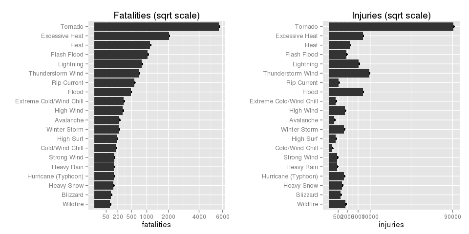

Figure 1 - Top 20 events in fatalities

```r
require(ggplot2)
require(gridExtra)

plot1 <- qplot(data = summary_fatal, x = EVTYPE2, y = sum) +
    geom_bar(stat="identity") + coord_flip() +
    scale_y_sqrt(breaks=c(50,200,500,1000,2000,4000,6000)) +
    xlab('') + ylab('fatalities') +
    ggtitle('Fatalities (sqrt scale)')

plot2 <- qplot(data = summary_injury, x = EVTYPE2, y = sum) +
    geom_bar(stat="identity") + coord_flip() +
    scale_y_sqrt(breaks=c(500,2000,5000,10000,90000)) +
    xlab('') + ylab('injuries') +
    ggtitle('Injuries (sqrt scale)')

grid.arrange(plot1, plot2, ncol=2)
```

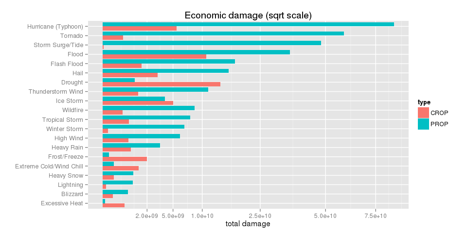

Figure 2 - Top 20 events economic damage

```r
ggplot(data = summary_dmg, aes(x=EVTYPE2, y=sum, fill=type)) +
    geom_bar(stat="identity", position="dodge") + coord_flip() +
    scale_y_sqrt(breaks=c(0.2e+10, 0.5e+10, 1e+10, 2.5e+10, 5.0e+10, 7.5e+10)) +
    xlab('') + ylab('total damage') +
    ggtitle("Economic damage (sqrt scale)")
```

Economic damage was done mostly by hurricanes (above all Katrina) followed by tornadoes and floods. Storm surge/tide are also hurricane-related as we saw in Outlier analysis section. All those events caused mostly property damage. Most crop damage was caused by drought.

```r
require(xtable)
print(xtable(summary), type = "html")
```

|  | EVTYPE2 | FATALITIES | INJURIES | PROPDMG | CROPDMG |
| --- | --- | --- | --- | --- | --- |
| 1 | Tornado | 5659 | 91364 | 58550.00 | 417.50 |
| 2 | Excessive Heat | 2019 | 6730 | 7.87 | 497.40 |
| 3 | Heat | 1129 | 2513 | 13.76 | 407.10 |
| 4 | Flash Flood | 1035 | 1800 | 17590.00 | 1532.00 |
| 5 | Lightning | 817 | 5232 | 935.50 | 12.09 |
| 6 | Thunderstorm Wind | 714 | 9537 | 11190.00 | 1272.00 |
| 7 | Rip Current | 577 | 529 | 0.16 | 0.00 |
| 8 | Flood | 483 | 6794 | 35250.00 | 10850.00 |
| 9 | Extreme Cold/Wind Chill | 314 | 260 | 133.30 | 1330.00 |
| 10 | High Wind | 293 | 1507 | 6003.00 | 686.30 |
| 11 | Avalanche | 225 | 170 | 3.72 | 0.00 |
| 12 | Winter Storm | 217 | 1353 | 6749.00 | 32.44 |
| 13 | High Surf | 179 | 259 | 111.60 | 0.00 |
| 14 | Cold/Wind Chill | 168 | 60 | 3.59 | 101.70 |
| 15 | Strong Wind | 141 | 407 | 193.60 | 71.02 |
| 16 | Hurricane (Typhoon) | 135 | 1333 | 85360.00 | 5516.00 |
| 17 | Heavy Rain | 136 | 387 | 3320.00 | 816.30 |
| 18 | Heavy Snow | 130 | 1035 | 953.70 | 134.70 |
| 19 | Blizzard | 101 | 805 | 659.80 | 112.10 |
| 20 | Wildfire | 90 | 1608 | 8497.00 | 403.30 |
| 21 | Ice Storm | 89 | 1977 | 3946.00 | 5022.00 |
| 22 | Winter Weather | 81 | 722 | 57.56 | 15.01 |
| 23 | Dense Fog | 80 | 1076 | 22.83 | 0.00 |
| 24 | Tropical Storm | 66 | 383 | 7715.00 | 694.90 |
| 25 | Debris Flow | 44 | 55 | 327.40 | 20.02 |
| 26 | Tsunami | 33 | 129 | 144.10 | 0.02 |
| 27 | Drought | 31 | 5 | 1046.00 | 13970.00 |
| 28 | Storm Surge/Tide | 25 | 44 | 47970.00 | 0.85 |
| 29 | Frost/Freeze | 23 | 213 | 40.45 | 1997.00 |
| 30 | Dust Storm | 22 | 440 | 5.62 | 3.60 |
| 31 | Marine Thunderstorm Wind | 19 | 34 | 5.86 | 0.05 |
| 32 | Hail | 15 | 1371 | 15980.00 | 3047.00 |
| 33 | Marine Strong Wind | 14 | 22 | 0.42 | 0.00 |
| 34 | Coastal Flood | 13 | 9 | 444.60 | 0.06 |
| 35 | Other | 9 | 14 | 1.17 | 143.00 |
| 36 | Freezing Fog | 8 | 232 | 3.49 | 0.00 |
| 37 | Waterspout | 6 | 72 | 60.73 | 0.00 |
| 38 | Dust Devil | 2 | 43 | 0.72 | 0.00 |
| 39 | Sleet | 2 | 0 | 2.00 | 0.00 |
| 40 | Marine High Wind | 1 | 1 | 1.30 | 0.00 |
| 41 | Funnel Cloud | 0 | 3 | 0.19 | 0.00 |
| 42 | Lake-Effect Snow | 0 | 0 | 40.68 | 0.00 |
| 43 | Lakeshore Flood | 0 | 0 | 7.57 | 0.00 |
| 44 | Tropical Depression | 0 | 0 | 1.77 | 0.00 |
| 45 | Seiche | 0 | 0 | 0.98 | 0.00 |
| 46 | Volcanic Ash | 0 | 0 | 0.50 | 0.00 |
| 47 | Astronomical Low Tide | 0 | 0 | 0.32 | 0.00 |
| 48 | Dense Smoke | 0 | 0 | 0.10 | 0.00 |
| 49 | Marine Hail | 0 | 0 | 0.00 | 0.00 |

Total damage by all events, economic damage is in millions of USD.